# Physiology

Debbie Leung

2/7/2021

## Set up

```r
# install.packages(c("ggplot2", "dplyr", "tidyr", "gridExtra", "cowplot", "lattice"))
library(ggplot2)
library(dplyr)
library(tidyr)
library(gridExtra)
library(cowplot)
library(lattice)
```

```r
mydata <- read.csv("physiology_data.csv", stringsAsFactors = FALSE) %>% na_if("")
df <- data.frame(mydata)
```

## Summary Statistics

```r
summary(df)
```

```
##   sample_no         heating_rate       tidal_height        time_point
##  Length:243         Length:243         Length:243         Length:243
##  Class :character   Class :character   Class :character   Class :character
##  Mode  :character   Mode  :character   Mode  :character   Mode  :character
##
##
##
##
##  experimental_day       sex             shell_length   average_weight
##  Length:243         Length:243         Min.   :34.90   Min.   : 4.558
##  Class :character   Class :character   1st Qu.:37.10   1st Qu.: 5.779
##  Mode  :character   Mode  :character   Median :38.70   Median : 6.492
##                                        Mean   :39.14   Mean   : 6.764
##                                        3rd Qu.:40.77   3rd Qu.: 7.657
##                                        Max.   :48.70   Max.   :11.043
##                                        NA's   :5       NA's   :90
##  weight_before     weight_after     weight_loss      weight_loss_percent
##  Min.   : 4.539   Min.   : 4.515   Min.   :-1.2910   Min.   :-0.22898
##  1st Qu.: 5.716   1st Qu.: 5.711   1st Qu.: 0.0370   1st Qu.: 0.00553
##  Median : 6.484   Median : 6.463   Median : 0.0670   Median : 0.01067
##  Mean   : 6.773   Mean   : 6.733   Mean   : 0.1139   Mean   : 0.01585
##  3rd Qu.: 7.740   3rd Qu.: 7.645   3rd Qu.: 0.1120   3rd Qu.: 0.01662
##  Max.   :11.161   Max.   :10.925   Max.   : 2.0450   Max.   : 0.25435
##  NA's   :82       NA's   :89       NA's   :90        NA's   :90
##    osmolality       heart_rate       average_temp      temp_sd
##  Min.   : 525.0   Min.   :0.08827   Min.   :24.80   Min.   :0.1232
##  1st Qu.: 952.5   1st Qu.:0.22060   1st Qu.:27.00   1st Qu.:0.3641
##  Median : 980.0   Median :0.25687   Median :32.50   Median :0.8036
##  Mean   : 993.6   Mean   :0.26551   Mean   :31.27   Mean   :0.7544
##  3rd Qu.:1043.2   3rd Qu.:0.31315   3rd Qu.:35.80   3rd Qu.:1.1078
##  Max.   :1262.0   Max.   :0.52253   Max.   :38.60   Max.   :1.4829
##  NA's   :85       NA's   :172       NA's   :150     NA's   :150
```

```r
str(df)
```

```
## 'data.frame':    243 obs. of  16 variables:
##  $ sample_no          : chr  "123" "17" "60" "8" ...
##  $ heating_rate       : chr  "M" "S" "F" "C" ...
##  $ tidal_height       : chr  "H" "L" "L" "L" ...
##  $ time_point         : chr  "T1" "T2" "T2" "T2_S" ...
##  $ experimental_day   : chr  "16/09/2020" "31/08/2020" "01/09/2020" "31/08/2020" ...
##  $ sex                : chr  "F" "F" "M" "F" ...
##  $ shell_length       : num  40.7 41.3 44.3 43.9 42.1 41.9 41.6 42.3 38.9 44.9 ...
##  $ average_weight     : num  6.91 11.04 10.98 10.96 10.52 ...
##  $ weight_before      : num  6.94 11.16 11.06 11.08 10.56 ...
##  $ weight_after       : num  6.88 10.93 10.9 10.85 10.49 ...
##  $ weight_loss        : num  0.054 0.236 0.161 0.225 0.072 0.321 0.338 -0.005 0.096 0.2 ...
##  $ weight_loss_percent: num  0.00779 0.02115 0.01455 0.02031 0.00682 ...
##  $ osmolality         : num  985 1086 943 948 971 ...
##  $ heart_rate         : num  0.262 0.228 0.308 NA 0.251 ...
##  $ average_temp       : num  NA NA NA NA NA NA NA NA NA NA ...
##  $ temp_sd            : num  NA NA NA NA NA NA NA NA NA NA ...
```

## Exploratory Figures

### Heart Rate

Generally confused the different combinations of plots I can literally plot by selecting the different factor variables. Also arrangement styles.

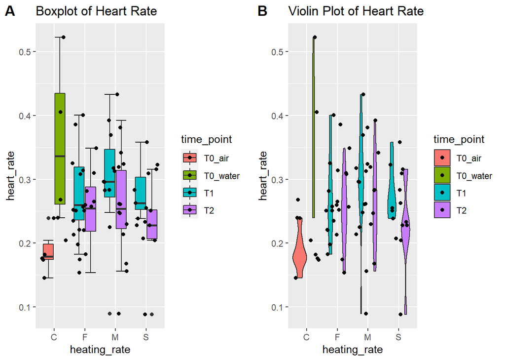

```r
# Compare box and violin plots
hr <- df %>% drop_na(heart_rate) # drop NA for heart rate, simultaneously filtering for H and L only

hr_box <- ggplot(data = hr, aes(x = heating_rate, y = heart_rate, fill=time_point)) + stat_boxplot(geom = "errorbar") + geom_boxplot() + geom_jitter() + ggtitle("Boxplot of Heart Rate")

hr_violin <- ggplot(data = hr, aes(x = heating_rate, y = heart_rate, , fill=time_point)) + geom_violin() + geom_jitter() + ggtitle("Violin Plot of Heart Rate")

# grid.arrange(hr_box, hr_violin, ncol = 2)
plot_grid(hr_box, hr_violin, labels = "AUTO")
```

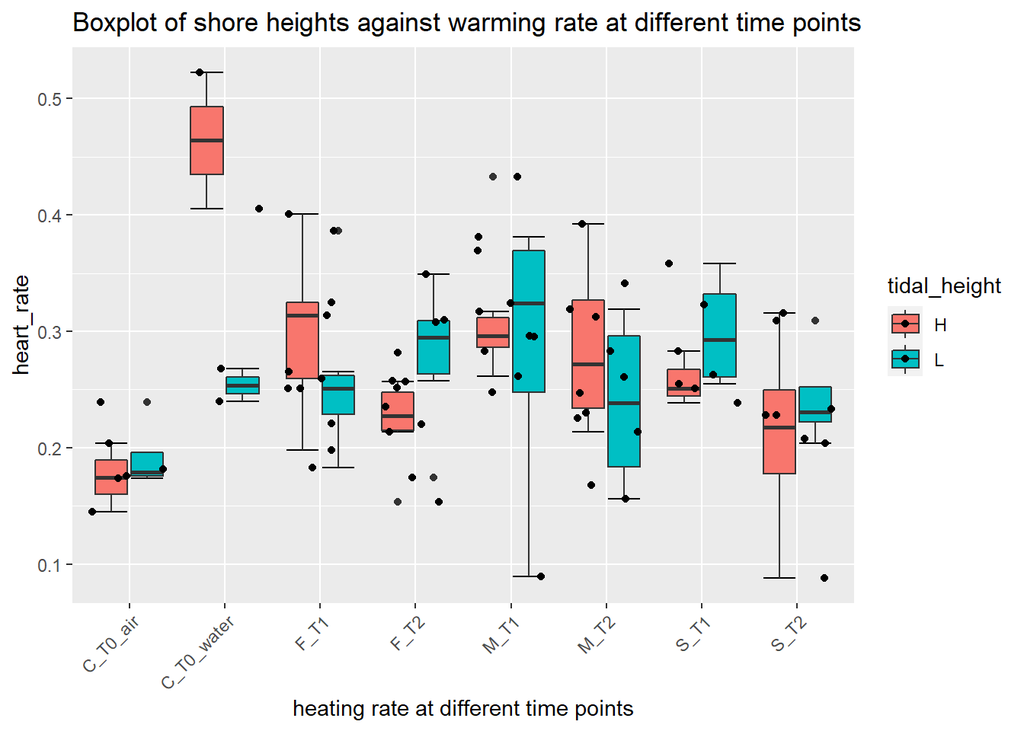

```r
# Compare high and low tidal heights at different time points

# Change to long pivot
hr_long <- hr %>% unite("rate_time", c("heating_rate", "time_point"), sep = "_", remove = FALSE)

hr_long <- within(hr_long, rm("heating_rate", "time_point"))

ggplot(data = hr_long, aes(x = rate_time, y = heart_rate, fill=tidal_height)) + stat_boxplot(geom = "errorbar") + geom_boxplot() + geom_jitter() + ggtitle("Boxplot of shore heights against warming rate at different time points") + theme(axis.text.x = element_text(angle=45, hjust=1)) + labs(x = "heating rate at different time points")
```

```r
# Can further split this into one with two time points side-by-side or two shore heights at different time points
```

### Osmolality

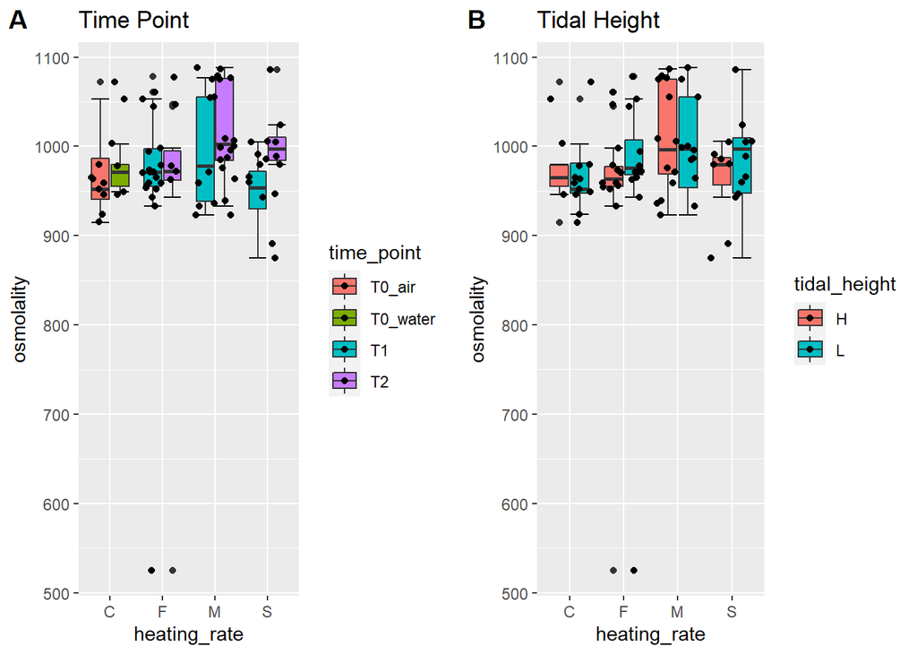

```r
osmo <- df %>% drop_na(osmolality)

osmo <- osmo %>% drop_na(time_point) # remove dummy controls with D

osmo <- subset(osmo, time_point == "T1" | time_point == "T2" | time_point == "T0_air" | time_point == "T0_water") # remove controls with T1_F/M/S or T2_F/M/S

osmo_tp <- ggplot(data = osmo, aes(x = heating_rate, y = osmolality, fill=time_point)) + stat_boxplot(geom = "errorbar") + geom_boxplot() + geom_jitter() + ggtitle("Time Point")

osmo_th <- ggplot(data = osmo, aes(x = heating_rate, y = osmolality, fill=tidal_height)) + stat_boxplot(geom = "errorbar") + geom_boxplot() + geom_jitter() + ggtitle("Tidal Height")

plot_grid(osmo_tp, osmo_th, labels = "AUTO")
```

Seems to have two outliers but I can only find one. Also every time I try to reproduce the graph, the two dots move position?!

Also not plotting seawater osmolality…

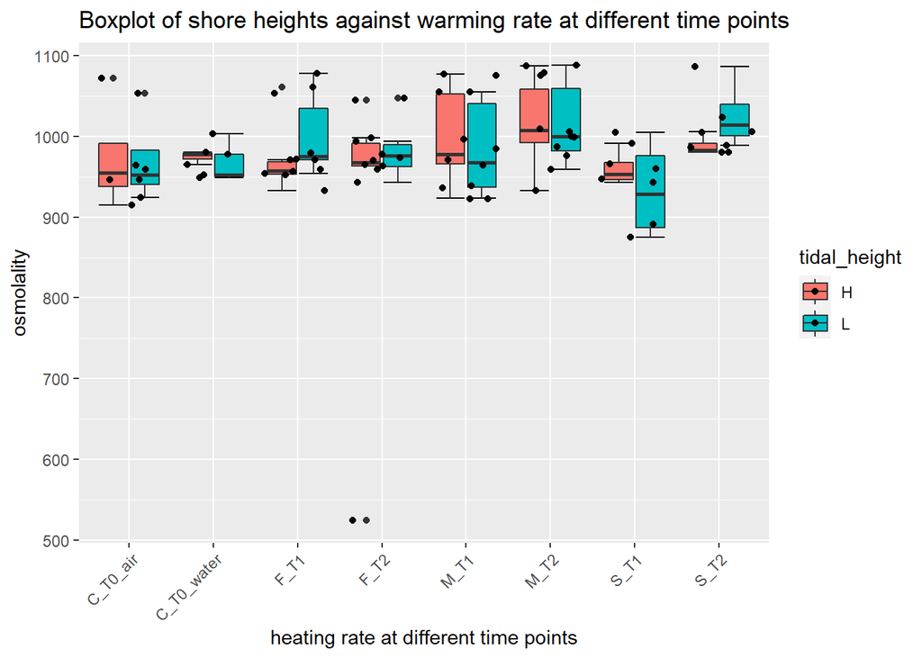

```r
# Compare high and low tidal heights at different time points

# Change to long pivot
osmo_long <- osmo %>% unite("rate_time", c("heating_rate", "time_point"), sep = "_", remove = FALSE)

osmo_long <- within(osmo_long, rm("heating_rate", "time_point"))

ggplot(data = osmo_long, aes(x = rate_time, y = osmolality, fill=tidal_height)) + stat_boxplot(geom = "errorbar") + geom_boxplot() + geom_jitter() + ggtitle("Boxplot of shore heights against warming rate at different time points") + theme(axis.text.x = element_text(angle=45, hjust=1)) + labs(x = "heating rate at different time points")
```

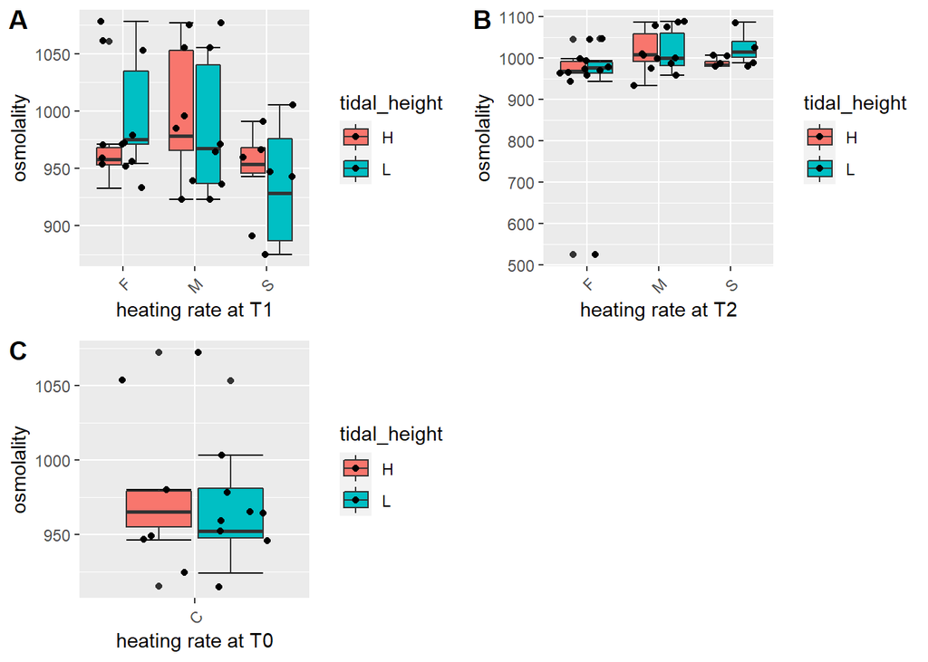

```r
# Further split this into one with two time points side-by-side or two shore heights at different time points
osmo_t0 <- subset(osmo, time_point == "T0_air" | time_point == "T0_water")
osmo_t1 <- subset(osmo, time_point == "T1")
osmo_t2 <- subset(osmo, time_point == "T2")

# Split side-by-side graphs: https://stackoverflow.com/questions/1249548/side-by-side-plots-with-ggplot2
# par(mfrow=c(1,2))
plot_t0 <-ggplot(data = osmo_t0, aes(x = heating_rate, y = osmolality, fill=tidal_height)) + stat_boxplot(geom = "errorbar") + geom_boxplot() + geom_jitter() + theme(axis.text.x = element_text(angle=45, hjust=1)) + labs(x = "heating rate at T0")

plot_t1 <- ggplot(data = osmo_t1, aes(x = heating_rate, y = osmolality, fill=tidal_height)) + stat_boxplot(geom = "errorbar") + geom_boxplot() + geom_jitter() + theme(axis.text.x = element_text(angle=45, hjust=1)) + labs(x = "heating rate at T1")

plot_t2 <- ggplot(data = osmo_t2, aes(x = heating_rate, y = osmolality, fill=tidal_height)) + stat_boxplot(geom = "errorbar") + geom_boxplot() + geom_jitter() + theme(axis.text.x = element_text(angle=45, hjust=1)) + labs(x = "heating rate at T2")

# grid.arrange(plot_t0, plot_t1, plot_t2, ncol=3)
plot_grid(plot_t1, plot_t2, plot_t0, labels = "AUTO")
```

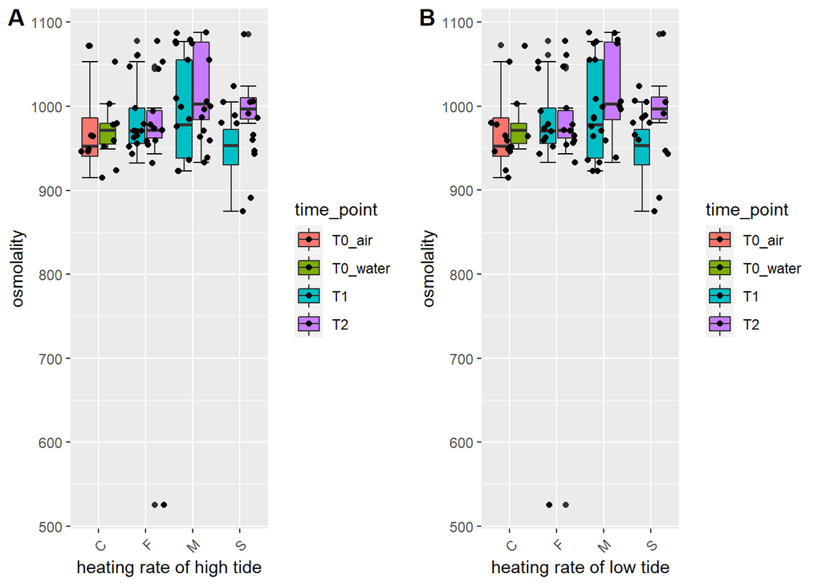

```r
osmo_h <- subset(osmo, tidal_height = "H")
osmo_l <- subset(osmo, tidal_height = "L")

plot_h <- ggplot(data = osmo_h, aes(x = heating_rate, y = osmolality, fill=time_point)) + stat_boxplot(geom = "errorbar") + geom_boxplot() + geom_jitter() + theme(axis.text.x = element_text(angle=45, hjust=1)) + labs(x = "heating rate of high tide")

plot_l <- ggplot(data = osmo_l, aes(x = heating_rate, y = osmolality, fill=time_point)) + stat_boxplot(geom = "errorbar") + geom_boxplot() + geom_jitter() + theme(axis.text.x = element_text(angle=45, hjust=1)) + labs(x = "heating rate of low tide")

# grid.arrange(plot_t0, plot_t1, plot_t2, ncol=3)
plot_grid(plot_h, plot_l, labels = "AUTO")
```

### Weight Loss

There are oddly points with negative weight loss…

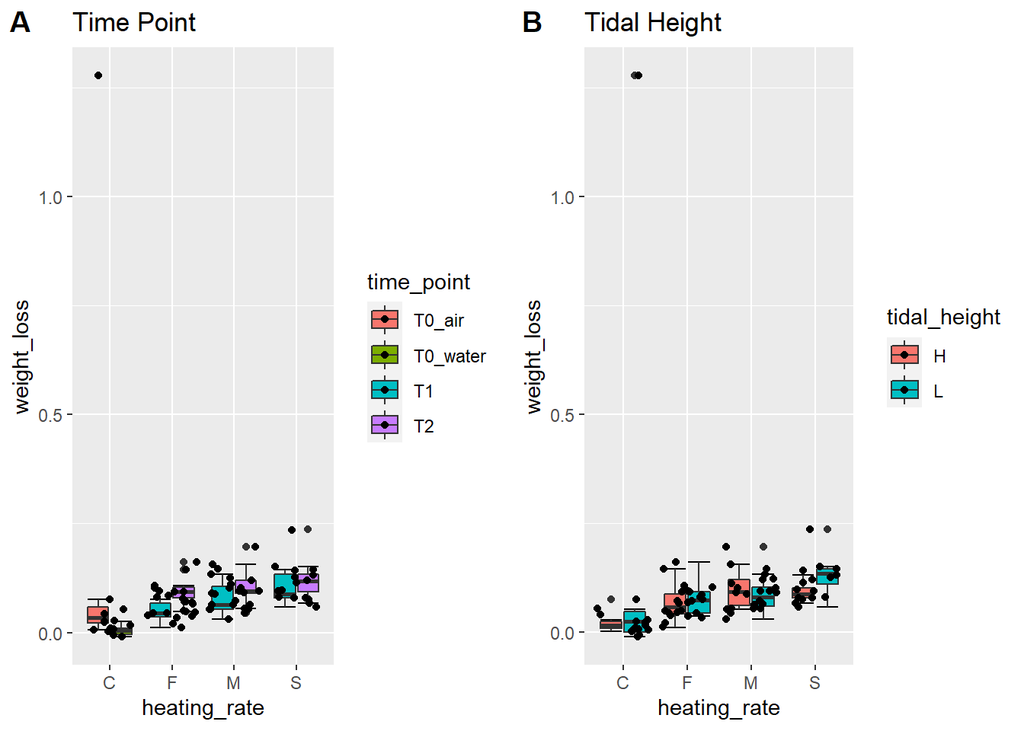

```r
# Plot both weight loss and weight loss percentage
wloss <- df %>% drop_na(weight_loss) %>% drop_na(time_point) # remove dummy controls with D
wloss <- subset(wloss, time_point == "T1" | time_point == "T2" | time_point == "T0_air" | time_point == "T0_water")

wloss_tp <- ggplot(data = wloss, aes(x = heating_rate, y = weight_loss, fill=time_point)) + stat_boxplot(geom = "errorbar") + geom_boxplot() + geom_jitter() + ggtitle("Time Point")

wloss_th <- ggplot(data = wloss, aes(x = heating_rate, y = weight_loss, fill=tidal_height)) + stat_boxplot(geom = "errorbar") + geom_boxplot() + geom_jitter() + ggtitle("Tidal Height")

plot_grid(wloss_tp, wloss_th, labels = "AUTO")
```

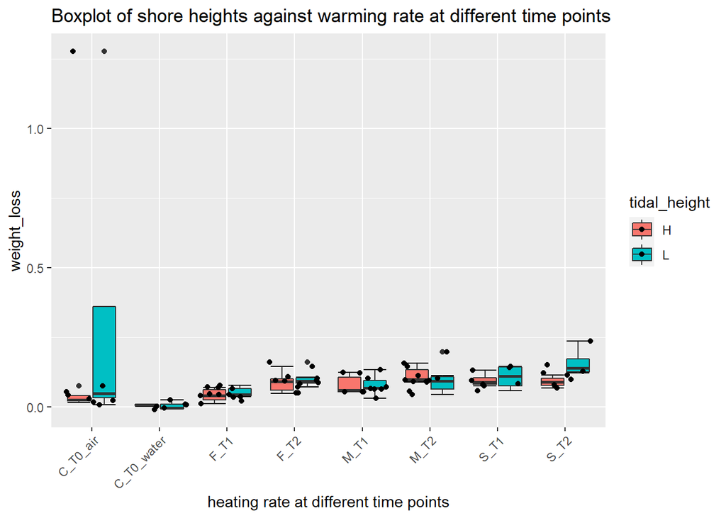

```r
# Compare high and low tidal heights at different time points

# Change to long pivot
wloss_long <- wloss %>% unite("rate_time", c("heating_rate", "time_point"), sep = "_", remove = FALSE)
wloss_long <- within(wloss_long, rm("heating_rate", "time_point"))

ggplot(data = wloss_long, aes(x = rate_time, y = weight_loss, fill=tidal_height)) + stat_boxplot(geom = "errorbar") + geom_boxplot() + geom_jitter() + ggtitle("Boxplot of shore heights against warming rate at different time points") + theme(axis.text.x = element_text(angle=45, hjust=1)) + labs(x = "heating rate at different time points")
```

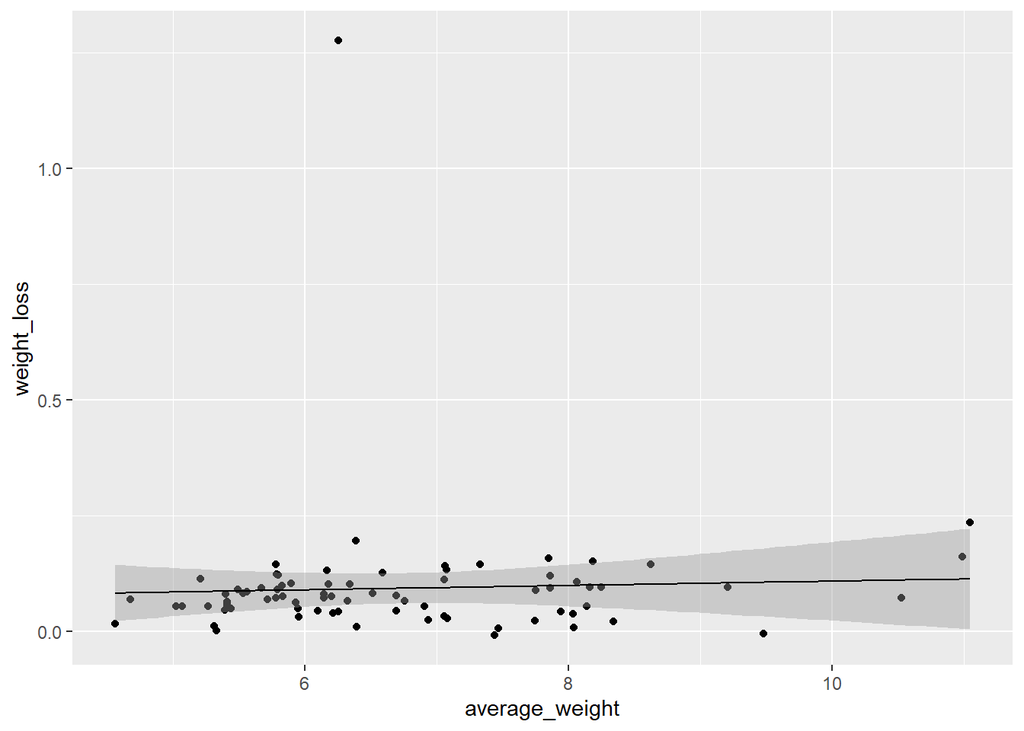

```r
# Check if weight loss is dependent on average weight
wloss_aw <- wloss %>% drop_na(average_weight)

ggplot(data = wloss_aw, aes(x = average_weight, y = weight_loss)) + geom_jitter() + geom_smooth(method='lm', size = 0.5, color = 'black')
```

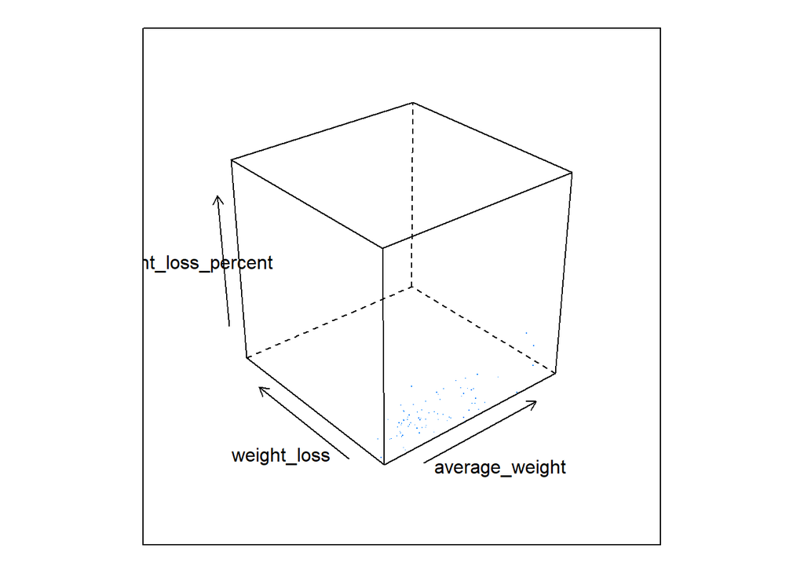

```r
# Check relationship between average weight, weight loss, weight loss percentage
cloud(weight_loss_percent ~ average_weight * weight_loss, pch = ".", data = wloss_aw)
```

Have not looked at weight_loss_percent as the dependent variable…

### Thermal Equilibrium

How to compare to water bath and surrounding air temperature? That data are recorded in the thermocouples, not by the thermal camera (I suppose we can put that in the appendix for additional reference?)

Values in red in the spreadsheet are not certain (I took the photos instead of Martin and they look blurry for the extra physiology group we did after the gene group) - should I remove them? or how to denote them as discrete colored points?

Is ggplot error bar different from the standard deviation I have calculated from the thermal camera?

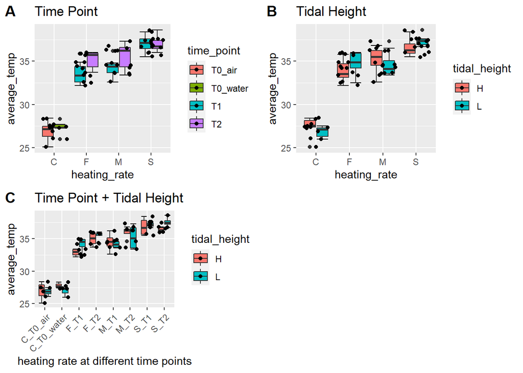

```r
tempavg <- df %>% drop_na(average_temp)
tempavg <- subset(tempavg, time_point == "T1" | time_point == "T2" | time_point == "T0_air" | time_point == "T0_water")

tempavg_tp <- ggplot(data = tempavg, aes(x = heating_rate, y = average_temp, fill=time_point)) + stat_boxplot(geom = "errorbar") + geom_boxplot() + geom_jitter() + ggtitle("Time Point")

tempavg_th <- ggplot(data = tempavg, aes(x = heating_rate, y = average_temp, fill=tidal_height)) + stat_boxplot(geom = "errorbar") + geom_boxplot() + geom_jitter() + ggtitle("Tidal Height")

# Compare high and low tidal heights at different time points
tempavg_long <- tempavg %>% unite("rate_time", c("heating_rate", "time_point"), sep = "_", remove = FALSE)
tempavg_long <- within(tempavg_long, rm("heating_rate", "time_point"))

tempavg_t <- ggplot(data = tempavg_long, aes(x = rate_time, y = average_temp, fill=tidal_height)) + stat_boxplot(geom = "errorbar") + geom_boxplot() + geom_jitter() + ggtitle("Time Point + Tidal Height") + theme(axis.text.x = element_text(angle=45, hjust=1)) + labs(x = "heating rate at different time points")

plot_grid(tempavg_tp, tempavg_th, tempavg_t, labels = "AUTO")
```

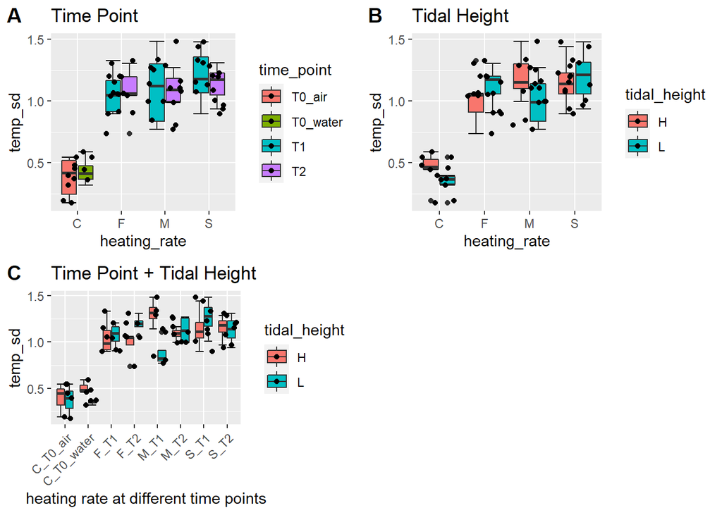

```r
tempsd <- df %>% drop_na(temp_sd)
tempsd <- subset(tempsd, time_point == "T1" | time_point == "T2" | time_point == "T0_air" | time_point == "T0_water")

tempsd_tp <- ggplot(data = tempsd, aes(x = heating_rate, y = temp_sd, fill=time_point)) + stat_boxplot(geom = "errorbar") + geom_boxplot() + geom_jitter() + ggtitle("Time Point")

tempsd_th <- ggplot(data = tempsd, aes(x = heating_rate, y = temp_sd, fill=tidal_height)) + stat_boxplot(geom = "errorbar") + geom_boxplot() + geom_jitter() + ggtitle("Tidal Height")

# Compare high and low tidal heights at different time points
tempsd_long <- tempsd %>% unite("rate_time", c("heating_rate", "time_point"), sep = "_", remove = FALSE)
tempsd_long <- within(tempsd_long, rm("heating_rate", "time_point"))

tempsd_t <- ggplot(data = tempsd_long, aes(x = rate_time, y = temp_sd, fill=tidal_height)) + stat_boxplot(geom = "errorbar") + geom_boxplot() + geom_jitter() + ggtitle("Time Point + Tidal Height") + theme(axis.text.x = element_text(angle=45, hjust=1)) + labs(x = "heating rate at different time points")

plot_grid(tempsd_tp, tempsd_th, tempsd_t, labels = "AUTO")
```

### Random Variables

How to check for dependent relationship between random variables and response variables? Check for effects of experimental day?

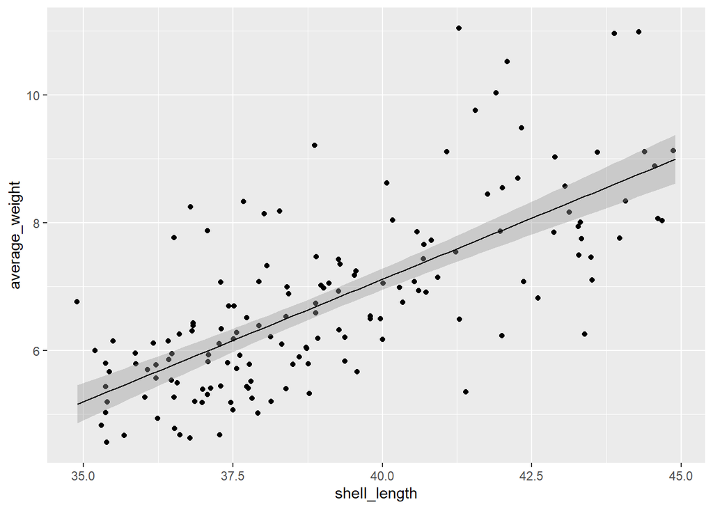

```r
# Check for positive relationship between shell length and average body weight
# Difference between geom_point() and geom_jitter()?

shell_weight <- df %>% drop_na(average_weight)

ggplot(data = shell_weight, aes(x = shell_length, y = average_weight)) + geom_jitter() + geom_smooth(method='lm', size = 0.5, color = 'black')
```

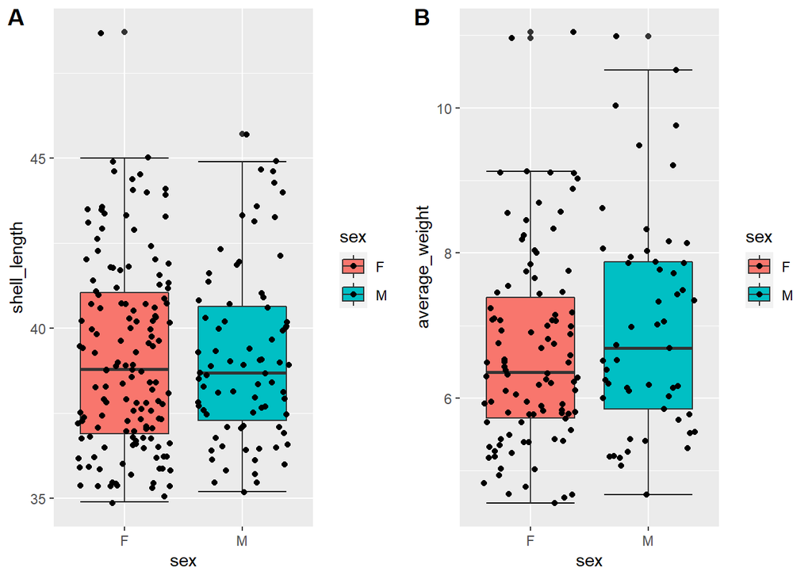

```r
# Check for relationship between sex and weight + sex and shell length

sex_shell <- df %>% drop_na(sex) %>% drop_na(shell_length)
sex_shell <- subset(sex_shell, sex == "F" | sex == "M") # remove F? and D in data

plot_shell <- ggplot(data = sex_shell, aes(x = sex, y = shell_length, fill = sex)) + stat_boxplot(geom = "errorbar") + geom_boxplot() + geom_jitter()

sex_weight <- subset(shell_weight, sex == "F" | sex == "M")

plot_weight <- ggplot(data = sex_weight, aes(x = sex, y = average_weight, fill = sex)) + stat_boxplot(geom = "errorbar") + geom_boxplot() + geom_jitter()

plot_grid(plot_shell, plot_weight, labels = "AUTO")
```

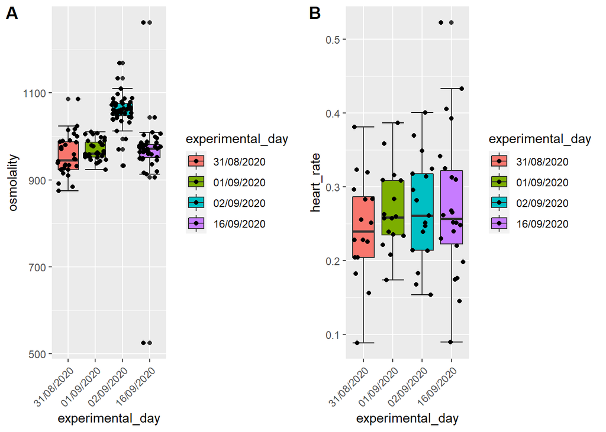

```r
# Check for effects of experimental day on heart rate and osmolality

day_osmo <- df %>% drop_na(osmolality) %>% drop_na(experimental_day)
day_osmo$experimental_day <- factor(day_osmo$experimental_day, levels = c("31/08/2020", "01/09/2020", "02/09/2020", "16/09/2020"))

plot_osmo <- ggplot(data = day_osmo, aes(x = experimental_day, y = osmolality, fill = experimental_day)) + stat_boxplot(geom = "errorbar") + geom_boxplot() + geom_jitter() + theme(axis.text.x = element_text(angle=45, hjust=1))

day_hr <- df %>% drop_na(heart_rate)
day_hr$experimental_day <- factor(day_hr$experimental_day, levels = c("31/08/2020", "01/09/2020", "02/09/2020", "16/09/2020"))

plot_hr <- ggplot(data = day_hr, aes(x = experimental_day, y = heart_rate, fill = experimental_day)) + stat_boxplot(geom = "errorbar") + geom_boxplot() + geom_jitter() + theme(axis.text.x = element_text(angle=45, hjust=1))

plot_grid(plot_osmo, plot_hr, labels = "AUTO")
```

Was also thinking of doing plots for experimental_day versus other variables to see if there are significant differences, but not sure if necessary since otherwise we could also do all random variables versus response variables…

## Publication Figures

Should we do any PCA diagram to group all the variables?